# Forest Fires in Portugal

Pedro Mota

Tatiana Araújo

# Introduction

Forest fires are a very important issue that negatively affects climate change. Typically, the causes of forest fires are those oversights, accidents and negligence committed by individuals, intentional acts and natural causes. The latter is the root cause for only a minority of the fires. Their harmful impacts and effects on ecosystems can be major ones. Among them, we can mention the disappearance of native species, the increase in levels of carbon dioxide in the atmosphere, the earth’s nutrients destroyed by the ashes, and the massive loss of wildlife. Data mining techniques can help in the prediction of the cause of the fire and, thus, better support the decision of taking preventive measures in order to avoid tragedy. In effect, this can play a major role in resource allocation, mitigation and recovery efforts. The ICFN - Nature and Forest Conservation Institute has the record of the list of forest fires that occurred in Portugal for several years. For each fire, there is information such as the site, the alert date/hour, the extinction date/hour, the affected area and the cause type (intentional, natural, negligent, rekindling or unknown).

The goal of this practical assignment is to build a machine learning model to predict the cause type of a forest fire: intentional or non-intentional.

For all the analysis, we used the language R and some of its packages from the CRAN, which we will load now:

```r
library(tidyverse)
library(dlookr)
library(lubridate)
library(cowplot)
library(caret)
library(naivebayes)
library(rpart)
library(rpart.plot)
library(adabag)
library(randomForest)
# library(ranger) - a faster implementation of random forests
library(xgboost)
```

# Data Importation

Read the .csv file, containing the training data, as a tibble.

```r
ds <- as_tibble(read_csv("fires_train.csv", na = c("-", "NA")))
glimpse(ds)
```

```
## Rows: 10,309
## Columns: 21
## $ id                 <dbl> 1, 2, 3, 4, 5, 6, 7, 8, 9, 10, 11, 12, 13, 14, 15, …
## $ region             <chr> "Trás-os-Montes", NA, "Entre Douro e Minho", "Trás-…
## $ district           <chr> "Bragança", "Viseu", "Aveiro", "Viseu", "Braga", "C…
## $ municipality       <chr> "Bragança", "Oliveira de Frades", "Vale de Cambra",…
## $ parish             <chr> "Zoio", "União das freguesias de Oliveira de Frades…
## $ lat                <chr> "41º44'17''", "40º46'55''", "40º51'11''", "41º4'16'…
## $ lon                <chr> "6º53'34''", "8º14'33''", "8º19'50''", "7º46'22''",…
## $ origin             <chr> "firepit", "firepit", "firepit", "firepit", "firepi…
## $ alert_date         <dttm> 2014-03-16 00:00:00, 2014-03-17 00:00:00, 2014-03-…
## $ alert_hour         <time> 16:15:00, 20:53:00, 12:55:00, 14:22:00, 12:07:00, …
## $ extinction_date    <dttm> 2014-03-16 00:00:00, 2014-03-17 00:00:00, 2014-03-…
## $ extinction_hour    <time> 17:47:00, 22:46:00, 15:30:00, 15:25:00, 13:14:00, …
## $ firstInterv_date   <dttm> 2014-03-16 00:00:00, 2014-03-17 00:00:00, 2014-03-…
## $ firstInterv_hour   <time> 16:35:00, 21:05:00, 13:10:00, 14:42:00, 12:07:00, …
## $ alert_source       <lgl> NA, NA, NA, NA, NA, NA, NA, NA, NA, NA, NA, NA, NA,…
## $ village_area       <dbl> 0.520, 0.000, 0.000, 0.000, 0.000, 0.073, 0.900, 0.…
## $ vegetation_area    <dbl> 0.0000, 0.0200, 0.0200, 0.0500, 0.2000, 0.0000, 0.0…
## $ farming_area       <dbl> 0.0000, 0.0000, 0.0000, 0.0000, 0.0000, 0.0000, 0.0…
## $ village_veget_area <dbl> 0.5200, 0.0200, 0.0200, 0.0500, 0.2000, 0.0730, 0.9…
## $ total_area         <dbl> 0.5200, 0.0200, 0.0200, 0.0500, 0.2000, 0.0730, 0.9…
## $ intentional_cause  <dbl> 0, 1, 0, 1, 0, 0, 0, 0, 0, 1, 1, 0, 0, 0, 0, 1, 1, …
```

One can see that, the columns *id*, *intentional_cause* and *origin* are wrongly typed. In order to do fix this, we convert them to their correct types:

```r
ds$id <- as.integer(ds$id)
ds$intentional_cause <- as.factor(ds$intentional_cause)
ds$origin <- as.factor(ds$origin)
```

# Data clean-up and pre-processing

Before we start the classification task, it’s very important that we access the quality of our data, since poor data quality poses several challenges to the effective data analysis.

We started by looking for **missing values** and **duplicate data**. In order to do that, we used the package *dlookr*.

```r
overview(ds)
```

```
##      division               metrics   value
## 1        size          observations   10309
## 2        size             variables      21
## 3        size                values  216489
## 4        size           memory size 2998376
## 5  duplicated duplicate observation       0
## 6     missing  complete observation       0
## 7     missing   missing observation   10309
## 8     missing     missing variables       6
## 9     missing        missing values   12157
## 10  data type              numerics       5
## 11  data type              integers       1
## 12  data type       factors/ordered       2
## 13  data type            characters       6
## 14  data type                 Dates       0
## 15  data type              POSIXcts       3
## 16  data type                others       4
```

As one can see, there’s no duplicate data, but there are a lot of missing values. So we went finding which columns have missing values and how many values are missing, per attribute:

```r
ds %>% select(find_na(.)) %>% diagnose()
```

```
## # A tibble: 6 × 6
##   variables        types  missing_count missing_percent unique_count unique_rate
##   <chr>            <chr>          <int>           <dbl>        <int>       <dbl>
## 1 region           chara…          1206          11.7             11   0.00107
## 2 extinction_date  POSIX…            11           0.107          549   0.0533
## 3 extinction_hour  hms               11           0.107         1258   0.122
## 4 firstInterv_date POSIX…           309           3.00           549   0.0533
## 5 firstInterv_hour hms              311           3.02          1256   0.122
## 6 alert_source     logic…         10309         100                1   0.0000970
```

From this diagnose, we can see that only the features *region*, *extinction_date*, *extinction_hour*, *firstInterv_date*, *firstInterv_hour* and *alert_source* have missing values.

In particular, the column *alert_source* is all missing values, so we can immediately drop it:

```r
ds <- select(ds, -alert_source)
```

Regarding the feature *region*, which is the one with more missing values (1206 in total), we don’t need to worry about imputating the data, since we think, for our analysis, the information given by the *region* is too much broader. The same analysis is applied to the attributes *municipality* and *parish*, but, in both of them, the information in them is too specific. Also, we have the attributes *lat* and *lon*, which completely determines the location of the fire. Hence, we just kept the *district* attribute, which is in a sweet spot between specificity and vagueness.

```r
ds <- select(ds, -c(region, municipality, parish))
```

Concerning the variable *district*, we went finding which districts and how many are there, in our data set.

```r
distinct(data.frame(ds$district))
```

```
##         ds.district
## 1          Bragança
## 2             Viseu
## 3            Aveiro
## 4             Braga
## 5    Castelo Branco
## 6  Viana do Castelo
## 7         Vila Real
## 8            Guarda
## 9            Leiria
## 10             Faro
## 11            Porto
## 12             Beja
## 13          Coimbra
## 14         Santarém
## 15            Évora
## 16       Portalegre
## 17          Setúbal
## 18           Lisboa
## 19 Viana Do Castelo
```

As we can see, there are 19 different districts, but, two of them (“Viana do Castelo” and “Viana Do Castelo”) refer to the same district (“Viana do Castelo”), due to capitalization. So we normalized all cases with “Viana Do Castelo” to “Viana do Castelo”:

```r
ds$district[ds$district == "Viana Do Castelo"] = "Viana do Castelo"
ds$district <- as.factor(ds$district)
```

Finally, the attributes related to the extinction and first intervation, since there are only a few missing cases, we didn’t bother imputating the data and probably adding bias to our data, so we just removed the observations where the missing values appeared.

```r
ds <- drop_na(ds)
find_na(ds)
```

```
## integer(0)
```

As one we can see, we don’t have any more missing values.

After this, we’ve found that the attribute *village_veget_area* and *total_area* are redundant, since they are just the sum of the feature *village_area* and *vegetation_area* and the the sum of the feature *village_area*, *vegetation_area* and *farming_area*, respectively, so we may drop them too.

Regarding the attributes *lat* and *lon*, the latitude and longitude coordinates of the location of the fire, respectively, they are represented as characters, which isn’t optimal for comparisons purposes. We could separate, for the latitude and longitude, the degrees, minutes and seconds measures and then convert them into numeric values, making a total of 6 features to represent the coordinates. Having 6 features representing the coordinates seemed exaggerated and we want to avoid the curse of high-dimensionality, so we look into other ways of representing the coordinates.

- The first idea was to convert the coordinates into a 3D coordinate space, where we would only have 3 features. Also, in the 3D coordinate space, close points are also close in reality, unlike in the coordinate system, where two extreme values can, actually, be very close together.
- The second idea was to convert the coordinates into a decimal representation. In this case, we have just 2 features to represent the coordinates and it’s already in the form that will need later, in order to get the temperatures.

With this in mind and since, in our case, we are only working with latitudes and longitudes within Portugal, which means there no extreme coordinates that are very close in reality, we the choosed the decimal representation.

```r
coordinate_to_decimal <- function(coordinate) {
  num = "(([0-9]+\\.[0-9]+)|([0-9]+))" # Regexp for integer and real numbers

  # Extract the numbers from the coordinate
  # Note that parsed_coordinate[1] is the degrees of the coordinate, parsed_coordinate[2] the minutes and parsed_coordinate[3] the seconds.
  parsed_coordinate <- as.double(str_extract_all(coordinate, num, simplify=TRUE))

  # Convert the coordinates to a decimal representation
  return (parsed_coordinate[1] + parsed_coordinate[2]/60 + parsed_coordinate[3]/3600)
}
coordinate_to_decimal = Vectorize(coordinate_to_decimal)

ds = mutate(ds, lat = coordinate_to_decimal(lat), lon = -1 * coordinate_to_decimal(lon))
```

Also, we’ve noticed that we have now missing values for the *lon* attribute. We suspected that was because of some strange values that couldn’t be parsed with the function *str_extract_all*, from the package *stringr*, so we went finding them.

```r
ds[is.na(ds$lon),]
```

```
## # A tibble: 3 × 15
##      id district   lat   lon origin     alert_date          alert_hour
##   <int> <fct>    <dbl> <dbl> <fct>      <dttm>              <time>
## 1  2522 Guarda    40.5    NA firepit    2014-05-15 01:00:00 02:08
## 2  6817 Santarém  39.4    NA firepit    2015-08-10 01:00:00 18:53
## 3  8690 Évora     39.0    NA agric_burn 2015-10-07 01:00:00 14:27
## # … with 8 more variables: extinction_date <dttm>, extinction_hour <time>,
## #   firstInterv_date <dttm>, firstInterv_hour <time>, village_area <dbl>,
## #   vegetation_area <dbl>, farming_area <dbl>, intentional_cause <fct>
```

Only 3 observations weren’t rightful parsed, which correspond to the IDs 2522, 6817 and 8690. Looking in the original data set, they have the following values for the *lon* attribute, respectively: 0.29930555555555555, 0.36041666666666666 and 0.31319444444444444. Looking at the values, they seem to already in a decimal representation. But, with further analysis as we will show after, we found this values to be outliers. So we may just drop it, already:

```r
ds <- drop_na(ds)
```

Regarding the *alert_data*, *extinction_date* and *firstInterv_date* datetime attributes, we assumed that the time field is wrong and we substituted them by the attributes *alert_hour*, *extinction_hour* and *firstInterv_hour* and we called these new attributes *alert_datetime*, *extinction_datetime* and *firstInterv_datetime*, respectively.

```r
ds$alert_date = as.Date(ds$alert_date)
ds$extinction_date = as.Date(ds$extinction_date)
ds$firstInterv_date = as.Date(ds$firstInterv_date)

ds <- mutate(ds, alert_datetime = with(ds, ymd(alert_date) + hms(alert_hour)))
ds <- mutate(ds, extinction_datetime = with(ds, ymd(extinction_date) + hms(extinction_hour)))
ds <- mutate(ds, firstInterv_datetime = with(ds, ymd(firstInterv_date) + hms(firstInterv_hour)))

ds <- select(ds, -c(alert_date, alert_hour, extinction_date, extinction_hour, firstInterv_date, firstInterv_hour))
```

Having almost fixed all data quality problems with the original data set, we tried to use our domain knowledge of the data to create new features, using the original ones, hoping that they will capture new important information much more efficiently than the original features, which will help us solving the problem.

These new features are:

- **part_of_day**: which is a factor attribute, having the values *morning*, *afternoon*, *evening* and *night*.
- **season**: which is a factor attribute, having the values *winter*, *spring*, *summer* and *autumn*.

We think these new attributes are helpful, since they may explain the origin of some natural causes, thus helping distinguish the cause of the fire, that is, our target variable.

For both of the new attributes, we made the assumption that the datetime given in the *alert_datetime* is a good approximation of the datetime of the starting of the fire, since a fire is, usually, immediately noticed.

To create the *part_of_day* attribute, we did the following:

```r
# Part of the day: part_of_day
# Morning 5 am to 12 pm (noon)
# Afternoon 12 pm to 5 pm.
# Evening 5 pm to 9 pm.
# Night 9 pm to 4 am.
getPartOfDay <- function (datetime) {
  classes <- factor(c('morning', 'afternoon', 'evening', 'night'), ordered = TRUE)

  hour = hour(datetime)

  if (5 <= hour & hour <= 12) return (classes[1])
  if (12 <= hour & hour <= 17) return (classes[2])
  if(17 <= hour & hour <= 21) return (classes[3])
  return (classes[4])
}
getPartOfDay = Vectorize(getPartOfDay)
ds = mutate(ds, part_of_day=getPartOfDay(alert_datetime))
```

And for the *season* attribute:

```r
getSeason <- function(datetime) {
  classes <- factor(c('winter', 'spring', 'summer', 'autumn'))
  day   = day(datetime)
  month = month(datetime)

  if(month == 1 | month == 2) return (classes[1])
  if(month == 3 & day <= 20) return (classes[1])
  if(month == 3 | month == 4 | month == 5) return (classes[2])
  if(month == 6 & day <= 20) return (classes[2])
  if(month == 6 | month == 7 | month == 8) return (classes[3])
  if(month == 9 & day <= 20) return (classes[3])
  if(month == 9 | month == 10 | month == 11) return (classes[4])
  if(month == 12 & day <= 20) return (classes[4])
  return (classes[1])
}
getSeason <- Vectorize(getSeason)
ds <- mutate(ds, season = getSeason(alert_datetime))
```

Also, regarding the *extinction_datetime* and the *firstInterv_datetime*, we think they can provide relevant information, but not as they are. That is, it’s irrelevant the datetime by itself, but the difference, in minutes, within them, may be useful. So we created the *time_combating* and *time_till_firstInterv* attributes, which are the time, in minutes, spent combating the fire and the time, in minutes, for the first intervation, respectively. Our hope is that there is some correlation between this new attributes and the target variable.

```r
ds <- mutate(ds, time_combating = as.integer(difftime(extinction_datetime, firstInterv_datetime, units="mins")))
ds <- mutate(ds, time_till_firstInterv = as.integer(difftime(firstInterv_datetime, alert_datetime, units="mins")))

ds <- select(ds, -c(alert_datetime, extinction_datetime, firstInterv_datetime))
```

Finally, we checked if there are outliers. Namely regarding the *lat* and *lon* attributes, as one can see in the boxplots below. We considered a value to be an outlier if it’s out of the range [1st Quartile - 1.5*IQR, 3st Quartile + 1.5*IQR].

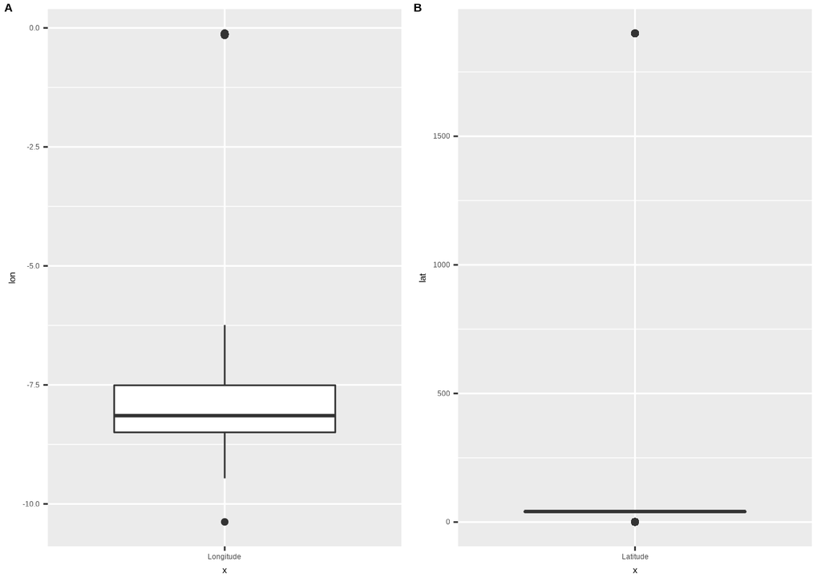

```r
lon_boxplot <- ggplot(ds) + geom_boxplot(aes(x = "Longitude", y=lon))
lat_boxplot <- ggplot(ds) + geom_boxplot(aes(x = "Latitude", y=lat))

plot_grid(lon_boxplot, lat_boxplot, labels = "AUTO")
```

We went further checking, for all numeric attributes, how many outliers are there:

```r
ds %>% summarize(across(c(where(is.numeric), -id), ~length(boxplot(., plot=FALSE)$out)))
```

```
## # A tibble: 1 × 7
##     lat   lon village_area vegetation_area farming_area time_combating
##   <int> <int>        <int>           <int>        <int>          <int>
## 1   912   858         2302            1690         2288            510
## # … with 1 more variable: time_till_firstInterv <int>
```

We just removed the outliers regarding the *lat* and *lon* attributes:

```r
lat_outliers <- boxplot.stats(ds$lat)$out
lon_outliers <- boxplot.stats(ds$lon)$out
ds = ds[-which(ds$lat %in% c(lat_outliers) | ds$lon %in% c(lon_outliers)),]
```

We didn’t remove the outliers from the other features, since we think that they aren’t noise, as in the *lat* and *lon*, but informative to our prediction task.

Relatively to the data cleaning and pre-processing, we are done. Regarding the normalization of the values, vital to some methods, that will be done after the exploratory analysis.

A final glimpse:

```r
ds = relocate(ds, intentional_cause, .after = last_col())
glimpse(ds)
```

```
## Rows: 9,074
## Columns: 13
## $ id                    <int> 1, 2, 3, 4, 5, 6, 7, 8, 9, 10, 11, 12, 13, 14, 1…
## $ district              <fct> Bragança, Viseu, Aveiro, Viseu, Braga, Castelo B…
## $ lat                   <dbl> 41.73806, 40.78194, 40.85306, 41.07111, 41.68222…
## $ lon                   <dbl> -6.892778, -8.242500, -8.330556, -7.772778, -8.2…
## $ origin                <fct> firepit, firepit, firepit, firepit, firepit, fir…
## $ village_area          <dbl> 0.520, 0.000, 0.000, 0.000, 0.000, 0.073, 0.900,…
## $ vegetation_area       <dbl> 0.0000, 0.0200, 0.0200, 0.0500, 0.2000, 0.0000, …
## $ farming_area          <dbl> 0.0000, 0.0000, 0.0000, 0.0000, 0.0000, 0.0000, …
## $ part_of_day           <fct> afternoon, evening, morning, afternoon, morning,…
## $ season                <fct> winter, winter, winter, winter, winter, winter, …
## $ time_combating        <int> 72, 101, 140, 43, 67, 182, 63, 65, 93, 35, 90, 7…
## $ time_till_firstInterv <int> 20, 12, 15, 20, 0, 20, 26, 39, 17, 16, 45, 11, 1…
## $ intentional_cause     <fct> 0, 1, 0, 1, 0, 0, 0, 0, 0, 1, 1, 0, 0, 0, 0, 1, …
```

# Data exploratory analysis

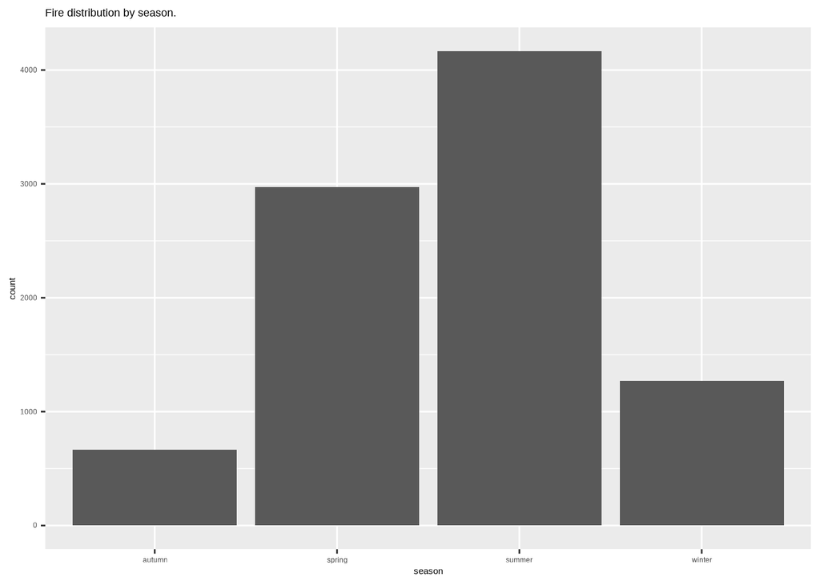

```r
ggplot(ds, aes(x = season)) + geom_bar() + ggtitle("Fire distribution by season.")
```

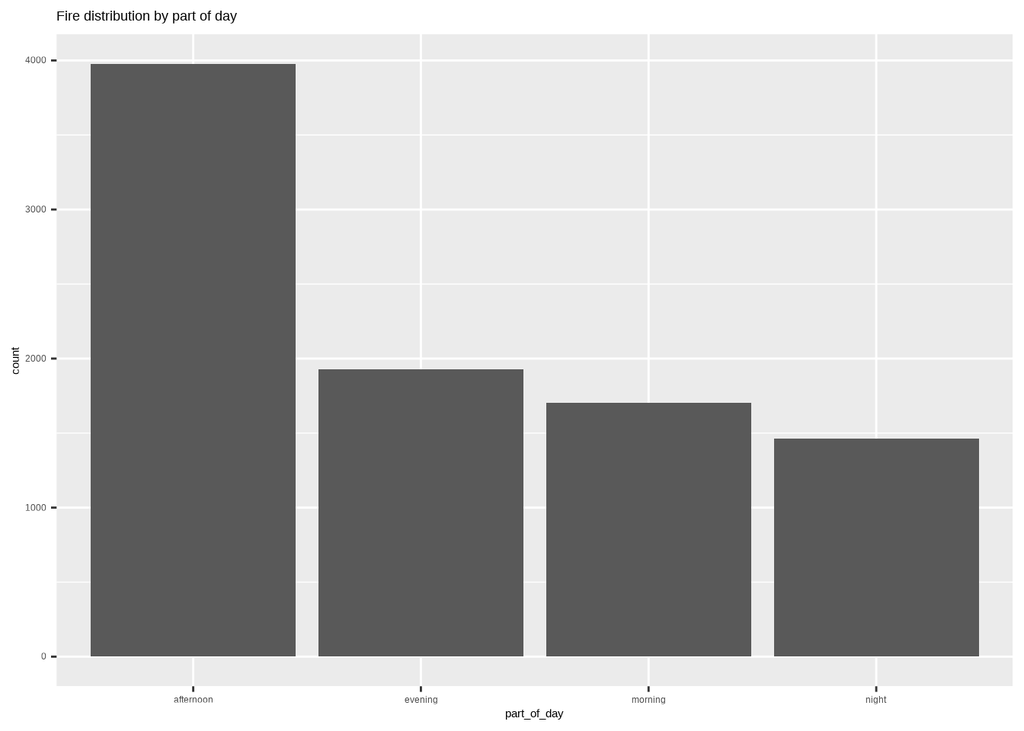

```r
ggplot(ds, aes(x = part_of_day)) + geom_bar() + ggtitle("Fire distribution by part of day")
```

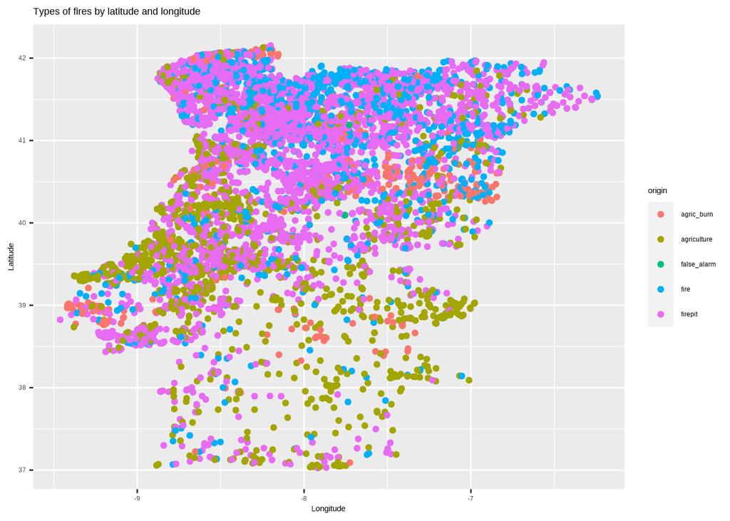

```r
ggplot(ds, aes(x=lon, y =lat)) + geom_point(aes(color=origin)) + ggtitle("Types of fires by latitude and longitude") + xlab("Longitude") + ylab("Latitude")
```

# Predictive modelling

We’ll now start, finally, the predictive modelling.

```r
ds <- select(ds, -id)
```

Firstly, we will try the k-Nearest Neighboors: 1) KNN

```r
fit <- train(intentional_cause ~ .,
             method     = "knn",
             tuneGrid   = expand.grid(k = seq(5, 30, by = 2)),
             trControl  = trainControl(method  = "cv", number = 10),
             metric     = "Accuracy",
             preProc    = c("center", "scale"),
             data       = ds)
fit
```

```
## k-Nearest Neighbors
##
## 9074 samples
##   11 predictor
##    2 classes: '0', '1'
##
## Pre-processing: centered (34), scaled (34)
## Resampling: Cross-Validated (10 fold)
## Summary of sample sizes: 8167, 8167, 8166, 8167, 8167, 8167, ...
## Resampling results across tuning parameters:
##
##   k   Accuracy   Kappa
##    5  0.7426677  0.3240113
##    7  0.7414574  0.3134420
##    9  0.7430006  0.3117117
##   11  0.7435504  0.3102251
##   13  0.7423365  0.3016739
##   15  0.7421161  0.2936164
##   17  0.7407938  0.2835277
##   19  0.7414550  0.2795261
##   21  0.7436586  0.2772415
##   23  0.7441001  0.2715076
##   25  0.7433284  0.2663241
##   27  0.7420067  0.2578665
##   29  0.7406838  0.2502583
##
## Accuracy was used to select the optimal model using the largest value.
## The final value used for the model was k = 23.
```

```r
set.seed(123)
inTrain <- createDataPartition(y = ds$intentional_cause, p = 0.7, list = FALSE)  # stratified random split of the data.
ds_train <- ds %>% dplyr::slice(inTrain)
ds_test <- ds %>% dplyr::slice(-inTrain)
ds_test_intentional_cause <- ds_test$intentional_cause
ds_test <- ds_test %>% select(-intentional_cause)
```

2. Naive Bayes

```r
nb.model <- naive_bayes(intentional_cause ~ ., data = ds_train, laplace=1)
nb.preds <- predict(nb.model, ds_test)
nb.confM <- confusionMatrix(ds_test_intentional_cause, nb.preds)
nb.confM
```

```
## Confusion Matrix and Statistics
##
##           Reference
## Prediction    0    1
##          0 1904   54
##          1  737   26
##
##                Accuracy : 0.7093
##                  95% CI : (0.6918, 0.7263)
##     No Information Rate : 0.9706
##     P-Value [Acc > NIR] : 1
##
##                   Kappa : 0.0089
##
##  Mcnemar's Test P-Value : <2e-16
##
##             Sensitivity : 0.72094
##             Specificity : 0.32500
##          Pos Pred Value : 0.97242
##          Neg Pred Value : 0.03408
##              Prevalence : 0.97060
##          Detection Rate : 0.69974
##    Detection Prevalence : 0.71959
##       Balanced Accuracy : 0.52297
##
##        'Positive' Class : 0
##
```

3. DT

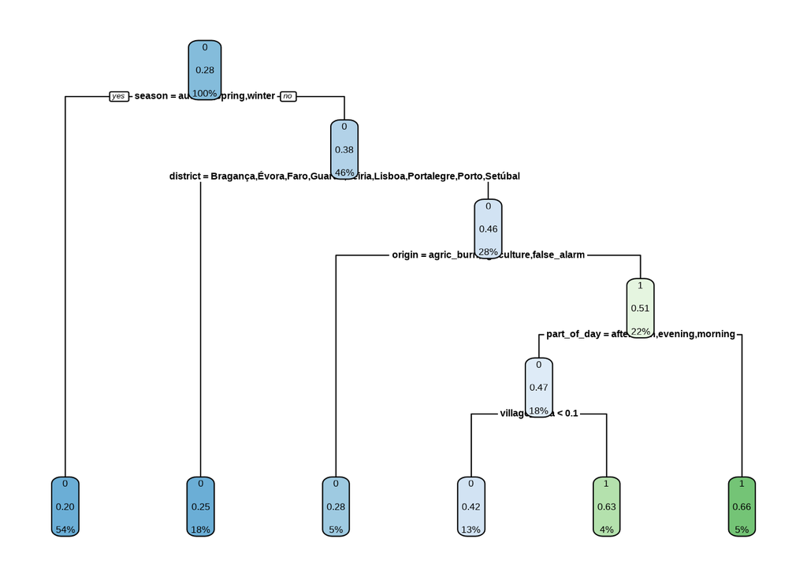

```r
treeDs <- rpart(intentional_cause ~ ., ds)
rpart.plot(treeDs)
```

```r
treeDs$variable.importance
```

```
##                season              district                origin
##            149.271109            108.512086             45.947440
##           part_of_day          farming_area          village_area
##             36.930524             36.237733             27.497103
##                   lon                   lat time_till_firstInterv
##             17.507211             14.763580             14.694524
##        time_combating       vegetation_area
##              8.525475              3.462140
```

```r
#treeDs$cptable
```

4. Ensemble approaches

```r
set.seed(123)
inTrain <- createDataPartition(y = ds$intentional_cause, p = 0.7, list = FALSE)
ds_train <- ds %>% dplyr::slice(inTrain)
ds_test <- ds %>% dplyr::slice(-inTrain)
```

4.1) Bagging

```r
#TODO: Fix this one. Taking a long time to construct the model
#m <- bagging(intentional_cause ~ ., ds_train, mfinal = 5, control = rpart.control(maxdepth = 3))
#preds <- predict(m, ds_test)
#confusionMatrix(as.factor(preds$class), ds_test_intentional_cause)
```

4.1) Random Forests

```r
m <- randomForest(intentional_cause ~ ., ds_train, importance = TRUE)
preds <- predict(m, ds_test)
confusionMatrix(preds, ds_test$intentional_cause)
```

```
## Confusion Matrix and Statistics
##
##           Reference
## Prediction    0    1
##          0 1787  416
##          1  171  347
##
##                Accuracy : 0.7843
##                  95% CI : (0.7683, 0.7996)
##     No Information Rate : 0.7196
##     P-Value [Acc > NIR] : 7.479e-15
##
##                   Kappa : 0.4074
##
##  Mcnemar's Test P-Value : < 2.2e-16
##
##             Sensitivity : 0.9127
##             Specificity : 0.4548
##          Pos Pred Value : 0.8112
##          Neg Pred Value : 0.6699
##              Prevalence : 0.7196
##          Detection Rate : 0.6567
##    Detection Prevalence : 0.8096
##       Balanced Accuracy : 0.6837
##
##        'Positive' Class : 0
##
```

```r
m$importance
```

```
##                                 0           1 MeanDecreaseAccuracy
## district              0.077984884 0.026588756          0.063545226
## lat                   0.042980050 0.022131161          0.037107805
## lon                   0.042793266 0.029605440          0.039077100
## origin                0.016045428 0.036019365          0.021640342
## village_area          0.009945965 0.029762283          0.015495843
## vegetation_area       0.012122925 0.015039654          0.012930742
## farming_area          0.007995841 0.005094314          0.007177405
## part_of_day           0.014208760 0.026465895          0.017653748
## season                0.016557918 0.030508048          0.020472631
## time_combating        0.004264015 0.001069170          0.003360500
## time_till_firstInterv 0.003619579 0.005102875          0.004041845
##                       MeanDecreaseGini
## district                     272.54683
## lat                          406.97653
## lon                          407.59329
## origin                        87.53105
## village_area                 185.13998
## vegetation_area              220.01516
## farming_area                  49.02989
## part_of_day                  163.08080
## season                       135.75599
## time_combating               309.32836
## time_till_firstInterv        255.88171
```

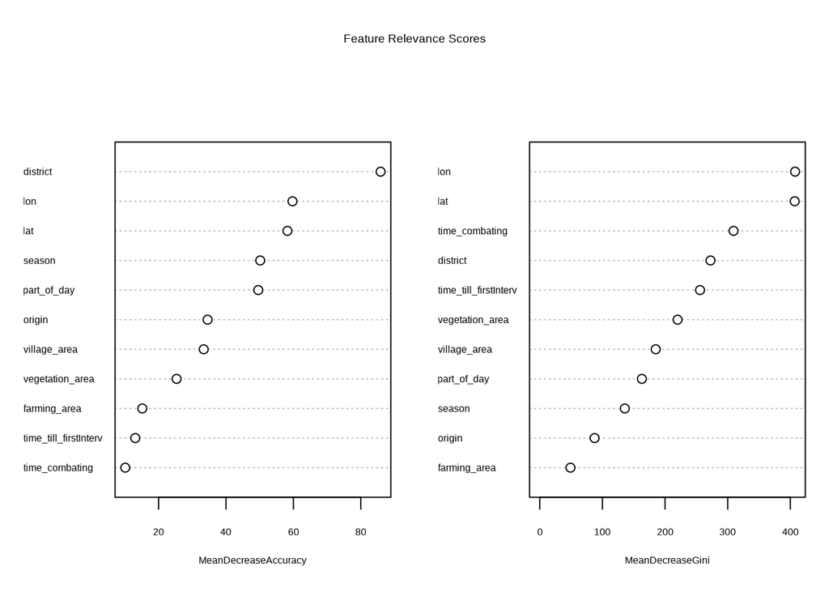

```r
varImpPlot(m, main = "Feature Relevance Scores")
```

4.2) AdaBoost

```r
#TODO: Fix this one. Taking a long time to construct the model
#m <- boosting(intentional_cause ~ ., ds_train, mfinal = 5, control = rpart.control(maxdepth = 3))
#preds <- predict(m, ds_test)
#confusionMatrix(factor(preds$class), ds_test$diabetes)
```

4.4) XGBoost

```r
m <- xgboost(data = data.matrix(select(ds, -intentional_cause)),
             label = as.integer(ds$intentional_cause)-1,
             #max.depth = 2, eta = 1, nthread = 2,
             nrounds = 100,
             objective = "binary:logistic",
             eval_metric = "logloss")
preds <- predict(m, data.matrix(select(ds, -intentional_cause)), reshape=T)

preds.class <- as.numeric(preds > 0.5)

confusionMatrix(factor(preds.class), factor(as.integer(ds$intentional_cause)-1))
```

```
## Confusion Matrix and Statistics
##
##           Reference
## Prediction    0    1
##          0 6321  459
##          1  207 2087
##
##                Accuracy : 0.9266
##                  95% CI : (0.921, 0.9319)
##     No Information Rate : 0.7194
##     P-Value [Acc > NIR] : < 2.2e-16
##
##                   Kappa : 0.8125
##
##  Mcnemar's Test P-Value : < 2.2e-16
##
##             Sensitivity : 0.9683
##             Specificity : 0.8197
##          Pos Pred Value : 0.9323
##          Neg Pred Value : 0.9098
##              Prevalence : 0.7194
##          Detection Rate : 0.6966
##    Detection Prevalence : 0.7472
##       Balanced Accuracy : 0.8940
##
##        'Positive' Class : 0
##
```

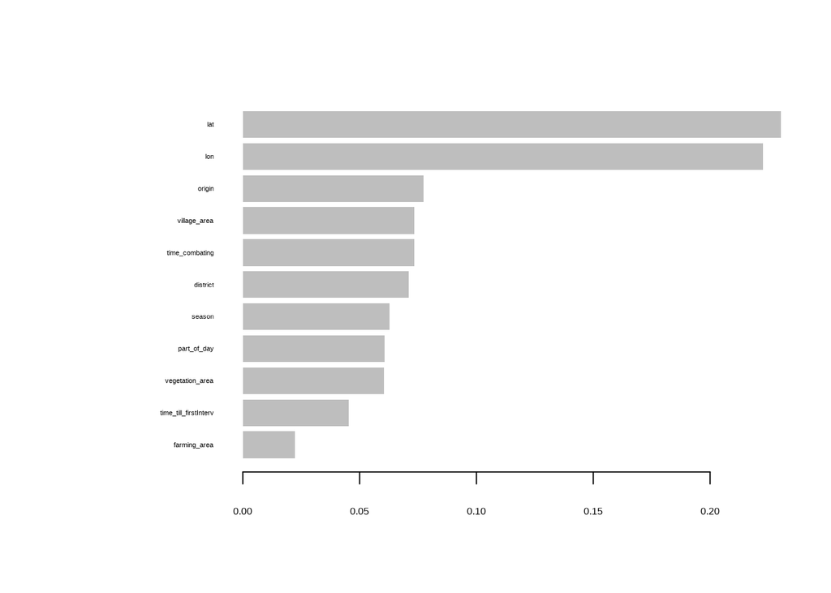

```r
varImp <- xgb.importance(model=m)
xgb.plot.importance(varImp)
```